# עבודה עם טבלאות

דן פלדמן

June 2017

[figure not shown]

# הקדמה

בשיעור הזה נתמקד בעבודה עם טבלאות נתונים - data frame. רוב העבודה שלכם מול R תהיה בעזרת טבלאות נתונים המניחים מבנה מסוים לנתונים שאותם מנתחים. בשיעור הזה נלמד איך לעבוד עם טבלאות בשפת הבסיס של R אבל בשיעורים הבאים נעשה שימוש בספריות חיצוניות כגון `dplyr` ו `sqldf` המקלות מאוד על עבודה עם טבלאות נתונים.

## מטרות

עד סוף השיעור תדעו:

- איך לגשת לטבלאות נתונים
- איך לבצע שאילתות על טבלאות הנתונים
- לבצע את כל הדברים שאתם רגילים לעשות בעולם ה Relational Database

# מבנה ה data.frame ב R

הרעיון מאחורי טבלת נתונים היא שכל שורה בטלה מייצגת תצפית ברמת ניתוח מסוימת, ועמודות הטבלה מכילים מאפיינים שונים עבור אותה תצפית. הרעיון של טבלת נתונים מיושם ב R בעזרת אובייקט ה data.frame שניתן לחשוב עליה ולגשת עליה בכמה אופנים:

- טבלה כמטריצה – ולכן ניתן לגשת עליה כאילו הייתה מטריצה
- טבלה כאוסף של וקטורים – data.frame היא מקרה פרטי של רשימה (list) המאגדת יחד וקטורים מסוגים שונים. ולכן, כל פעולה שעשינו על וקטורים ניתן לעשות לעמודות של data.frame

# גישה ל data.frame

כאמור, בכל סוגי המבנים ניתן לגשת לנתונים באחד מ 3 דרכים:

- בחירת נתונים לפי מקום
- בחירת נתונים לפי תנאי (ערך לוגי)
- בחירת נתונים לפי שם

בהמשך השיעור נתן דוגמאות על טבלת `iris` המובנית בתוך R

קודם בא נשמור גרסא מקומית של אותו טבלה שעליה נוכל להדגים:

```r
irisdata <- iris
```

## גישה לנתונים לפי מיקום

כאמור, טבלה היא סוג של מטריצה, וכל הכללים שלמדנו בשיעור הקודם על גישה לנותנים במטריצות חלים גם כאן.

- ניתן לגשת לנתונים בטבלה בצורה הבאה:

```r
TableName[Row Index, Coloumn Index]
```

לדוגמא:

```r
# Rows 1 to 5; Coloumns 1,3,4
irisdata[1:5, c(1,3,4)]
```

| Sepal.Length | Petal.Length | Petal.Width |
| --- | --- | --- |
| 5.1 | 1.4 | 0.2 |
| 4.9 | 1.4 | 0.2 |
| 4.7 | 1.3 | 0.2 |
| 4.6 | 1.5 | 0.2 |
| 5.0 | 1.4 | 0.2 |

- החלפת נתונים במיקום ספציפי באותה צורה כמו במטריצות:

לדוגמא:

```r
irisdata[1:2, 2:3] <- NA

irisdata[1:5, c(1,2,3)]
```

| Sepal.Length | Sepal.Width | Petal.Length |
| --- | --- | --- |
| 5.1 | NA | NA |
| 4.9 | NA | NA |
| 4.7 | 3.2 | 1.3 |
| 4.6 | 3.1 | 1.5 |
| 5.0 | 3.6 | 1.4 |

## גישה לנתונים לפי תנאי

כמו בוקטורים ומטריצות ניתן לבחור לפי תנאי. בדרך כלל נרצה לשים תנאי על עמודה מסוימת, על זה נלמד בהמשך השיעור. אבל אחד הפעולות הנפוצות לבצע על תנאי על טבלה שלמה היא לטיפול בערכים חסרים או להחליף ערך מסוים הנמצא בכל הטבלה. הפקודה is.na מחזיר ערך לוגי לכל ערך בווקטור, TRUE עם הערך חסר ו FALSE עם הערך לא חסר.

```r
# Replace Missing data with default value
irisdata[is.na(irisdata)] <- 9999

irisdata[1:5, c(1,2,3)]
```

| Sepal.Length | Sepal.Width | Petal.Length |
| --- | --- | --- |
| 5.1 | 9999.0 | 9999.0 |
| 4.9 | 9999.0 | 9999.0 |
| 4.7 | 3.2 | 1.3 |
| 4.6 | 3.1 | 1.5 |
| 5.0 | 3.6 | 1.4 |

## גישה לנתונים לפי שם

גם במטריצות ווקטורים ניתן לתת שמות לעמודות ולשורות, עם זאת האובייקט הנפוץ ביותר לשימוש בשמות הוא טבלה data.frame המקשר בין וקטורים שונים.

ה syntax לשלוף נתון מתוך טבלה היא:

```r
TableName$ColumnName[RowNumber]
```

- השמטת החלק של השורה תחזיר את כל העמודה.

לדוגמא:

```r
# Show the first 5 values
irisdata$Sepal.Length[1:5]
```

```
## [1] 5.1 4.9 4.7 4.6 5.0
```

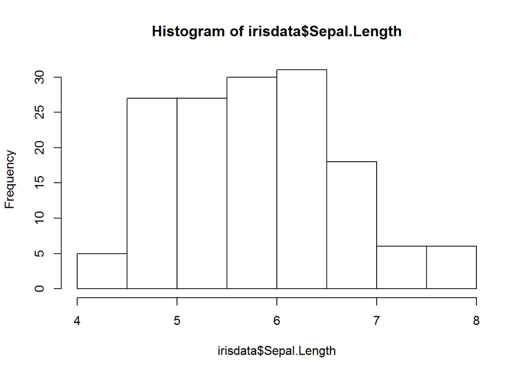

```r
# We can use a coloumn directly like any other vector

hist(irisdata$Sepal.Length)
```

# שאילתות על טבלאות

כמו בכל דבר ב R , הכוח האמיתי בא כשמשלבים בין השיטות השונות של גישה לטבלאות. כלומר גם גישה לטבלה עם שמות עמודות וגם כמטריצה לפי מקום ותנאים.

עכשיו שהבנו את העקרונות של גישה לטבלאות בוא נראה איך אפשר לשלב ביניהם לבצע שאילתות על הטבלה.

## שאילתות בסיסיות

לבחירת שאילתא על טבלה, מכניסים את התנאי למקום הראשון ואת העמודה שרוצים בחזרה במקום השני.

- הסינטקס הבסיסי לשאילתא היא:

```
Table[Condition, Columns]
```

- ניתן לבחור את העמודה הרצויה לפי מקום, לדוגמא:

```r
# One Coloumn
irisdata[irisdata$Sepal.Length>7.6,1]
```

```
## [1] 7.7 7.7 7.7 7.9 7.7
```

- או לבחור טווח של עמודות רציפות בעזרת הפעולה `:`

```r
# Consecutive Coloumns
irisdata[irisdata$Sepal.Length>7.6,1:3]
```

|  | Sepal.Length | Sepal.Width | Petal.Length |
| --- | --- | --- | --- |
| 118 | 7.7 | 3.8 | 6.7 |
| 119 | 7.7 | 2.6 | 6.9 |
| 123 | 7.7 | 2.8 | 6.7 |
| 132 | 7.9 | 3.8 | 6.4 |
| 136 | 7.7 | 3.0 | 6.1 |

- אם רוצים עמודות ספציפיות מאגדים אותם בעזרת האופרטור `c`

```r
# Specific Coloumns
irisdata[irisdata$Sepal.Length>7.6,c(1,3,5)]
```

|  | Sepal.Length | Petal.Length | Species |
| --- | --- | --- | --- |
| 118 | 7.7 | 6.7 | virginica |
| 119 | 7.7 | 6.9 | virginica |
| 123 | 7.7 | 6.7 | virginica |
| 132 | 7.9 | 6.4 | virginica |
| 136 | 7.7 | 6.1 | virginica |

- וגם ניתן לבחור את העמודות הרצויות לפי שם, לדוגמא:

```r
# One Coloumn
## Option 1
irisdata[irisdata$Sepal.Length>7.6,"Sepal.Length"]
```

```
## [1] 7.7 7.7 7.7 7.9 7.7
```

```r
## Option 2
irisdata$Sepal.Length[irisdata$Sepal.Length>7.6]
```

```
## [1] 7.7 7.7 7.7 7.9 7.7
```

```r
# Multiple Coloumns
irisdata[irisdata$Sepal.Length>7.6,c("Species", "Sepal.Length","Sepal.Width")]
```

|  | Species | Sepal.Length | Sepal.Width |
| --- | --- | --- | --- |
| 118 | virginica | 7.7 | 3.8 |
| 119 | virginica | 7.7 | 2.6 |
| 123 | virginica | 7.7 | 2.8 |
| 132 | virginica | 7.9 | 3.8 |
| 136 | virginica | 7.7 | 3.0 |

- אם רוצים את כל עמודות הטבלה אז משאירים את המקום השני ריק (אבל חייבים פסיק):

```r
irisdata[irisdata$Sepal.Length>7.6,]
```

|  | Sepal.Length | Sepal.Width | Petal.Length | Petal.Width | Species |
| --- | --- | --- | --- | --- | --- |
| 118 | 7.7 | 3.8 | 6.7 | 2.2 | virginica |
| 119 | 7.7 | 2.6 | 6.9 | 2.3 | virginica |
| 123 | 7.7 | 2.8 | 6.7 | 2.0 | virginica |
| 132 | 7.9 | 3.8 | 6.4 | 2.0 | virginica |
| 136 | 7.7 | 3.0 | 6.1 | 2.3 | virginica |

**החלפת ערכים בעמודה מסוימת כשהשורה עומדת בתנאי מסוים נעשית באותו שיטה.**

```r
# Replace
irisdata[irisdata$Sepal.Length>7.6,c("Sepal.Length","Sepal.Width")] <- 9999

# Show
irisdata[irisdata$Sepal.Length>7.6,]
```

|  | Sepal.Length | Sepal.Width | Petal.Length | Petal.Width | Species |
| --- | --- | --- | --- | --- | --- |
| 118 | 9999 | 9999 | 6.7 | 2.2 | virginica |
| 119 | 9999 | 9999 | 6.9 | 2.3 | virginica |
| 123 | 9999 | 9999 | 6.7 | 2.0 | virginica |
| 132 | 9999 | 9999 | 6.4 | 2.0 | virginica |
| 136 | 9999 | 9999 | 6.1 | 2.3 | virginica |

### פקודת `subset`

כיוון ששאילתא בסיסית היא פעולה נפוצה , קיימת ב R פונקציה בשם subset, המקלה על כתיבת השאילתא:

מבנה הפקודה היא:

```r
subset(TableName, Condition, Coloumns)
```

למשל:

```r
subset(irisdata, Sepal.Width==9999, c("Sepal.Length","Sepal.Width"))
```

|  | Sepal.Length | Sepal.Width |
| --- | --- | --- |
| 1 | 5.1 | 9999 |
| 2 | 4.9 | 9999 |
| 118 | 9999.0 | 9999 |
| 119 | 9999.0 | 9999 |
| 123 | 9999.0 | 9999 |
| 132 | 9999.0 | 9999 |
| 136 | 9999.0 | 9999 |

**בתוך ה `c` בבחירת העמודות לא חייבים את הגרשיים אבל זה מקרה יוצא דופן**

## שאילתות אגרגטיביות

פעולה נפוצה מאוד בניתוח נתונים היא לבצע סטטיסטיקות שונות לפי רמות של משתנה מסוים.

הדרך לעשות זאת ב R היא להשתמש באחד הפקודות הבאות המובדלים באובייקט שהן מחזירות ובהתאם במספר הפונקציות שהן יכולות לבצע במקביל.

### פקודה כללית `tapply`

פקודה ממשפחת ה `apply` שמבצעות איזשהו פעולה על כל ערך ברשימה. שתי הפקודות הבאות בנויות על פקודה זו. בהמשך הקורס נבין בדיוק איך הפקודה הזו עובדת.

- הפקודה מבצעת חישוב כלשהו לפי רמות של משתנה, ומחזירה וקטור.
- בפקודה ניתן לבצע מספר סטטיסטיקות או פונקציה כללית על משתנה המטרה.
- הסינטקס הבסיסית של הפקודה היא:

```r
tapply(Table$Coloumn, Table$GroupColoumn, Computation)
```

### פקודת `by`

- הפקודה מבצעת חישוב כלשהו לפי רמות של משתנה, ומחזירה מערך list.
- בפקודה ניתן לבצע מספר סטטיסטיקות או פונקציה כללית על משתנה המטרה.
- הסינטקס הבסיסית של הפקודה היא:

```r
by(Table$Coloumn, Table$GroupColoumn, Computation)
```

### פקודת `aggregate`

- הפקודה מבצעת חישוב כלשהו לפי רמות של משתנה, ומחזירה טבלה.
- בפקודה ניתן לבצע סטטיסטיקה אחת על משתנה המטרה.
- ניתן לבצע על מספר משתני מטרה, ועל צירוף של מספר משתני קבוצה.
- הסינטקס הבסיסית של הפקודה היא:

```r
aggregate(Table$Coloumn, Table$GroupColoumn, Computation)

# Or

aggregate(Coloumn ~ GroupColoumn, data = Table, Computation)
```

- הסינטקס עבור מספר משתני מטרה:

```r
aggregate(cbind(Table$Col1,Table$Col2), Table$GroupColoumn, Computation)

# Or

aggregate(cbind(Col1,Col2) ~ GroupColoumn, data = Table, Computation)
```

- הסינטקס עבור מספר משתני קבוצה היא:

```r
aggregate(Table$Coloumn, list(Table$Group1,Table$Group2), Computation)

# Or

aggregate(Coloumn ~ Group1 + Group2, data = Table, Computation)
```

*לרוב נשתמש בפקודה `aggregate` כי היא נוחה יותר בעבודה עם טבלאות.*

**הסינטקס של `aggregate` הוא בסגנון נוסחא של R ועוד נתקל בה בהמשך**

בדוגמא הבאה נבצע את אותו חישובים לפי כל אחד מהפונקציות הללו:

```r
tapply(irisdata$Sepal.Length, irisdata$Species, summary)
```

```
## $setosa
##    Min. 1st Qu.  Median    Mean 3rd Qu.    Max.
##   4.300   4.800   5.000   5.006   5.200   5.800
##
## $versicolor
##    Min. 1st Qu.  Median    Mean 3rd Qu.    Max.
##   4.900   5.600   5.900   5.936   6.300   7.000
##
## $virginica
##     Min.  1st Qu.   Median     Mean  3rd Qu.     Max.
##    4.900    6.225    6.500 1006.000    6.900 9999.000
```

```r
by(irisdata$Sepal.Length, irisdata$Species, summary)
```

```
## irisdata$Species: setosa
##    Min. 1st Qu.  Median    Mean 3rd Qu.    Max.
##   4.300   4.800   5.000   5.006   5.200   5.800
## --------------------------------------------------------
## irisdata$Species: versicolor
##    Min. 1st Qu.  Median    Mean 3rd Qu.    Max.
##   4.900   5.600   5.900   5.936   6.300   7.000
## --------------------------------------------------------
## irisdata$Species: virginica
##     Min.  1st Qu.   Median     Mean  3rd Qu.     Max.
##    4.900    6.225    6.500 1006.000    6.900 9999.000
```

```r
aggregate(Sepal.Length ~ Species, data = irisdata, mean)
```

| Species | Sepal.Length |
| --- | --- |
| setosa | 5.006 |
| versicolor | 5.936 |
| virginica | 1005.714 |

# שינויים במבנה טבלה

השינויים הבסיסיים שנרצה לבצע על טבלה הינם:

- הוספת ומחיקת עמודות
- שינוי שמות עמודות

## הוספת עמודה לטבלה

אפשר להוסיף עוד עמודה או דרך חישוב ישיר או על ידי הוספת וקטור בתור עוד עמודה בטבלה.

### הוספת עמודה בצורה ישירה

ניתן להוסיף עמודה בצורה ישירה לפי הסינטקס הבא:

```r
Table$Column <- Value
```

לדוגמא:

```r
# Add a constant value of 5
irisdata$NewCol <- 5
head(irisdata)
```

| Sepal.Length | Sepal.Width | Petal.Length | Petal.Width | Species | NewCol |
| --- | --- | --- | --- | --- | --- |
| 5.1 | 9999.0 | 9999.0 | 0.2 | setosa | 5 |
| 4.9 | 9999.0 | 9999.0 | 0.2 | setosa | 5 |
| 4.7 | 3.2 | 1.3 | 0.2 | setosa | 5 |
| 4.6 | 3.1 | 1.5 | 0.2 | setosa | 5 |
| 5.0 | 3.6 | 1.4 | 0.2 | setosa | 5 |
| 5.4 | 3.9 | 1.7 | 0.4 | setosa | 5 |

- חישוב עמודה חדשה על בסיס עמודה קיימת תעשה באותה צורה.

לדוגמא לחשב את היחס בין אורך עלה לבין הרוחב שלו:

```r
irisdata$NewCol <- irisdata$Sepal.Length/irisdata$Sepal.Width
head(irisdata)
```

| Sepal.Length | Sepal.Width | Petal.Length | Petal.Width | Species | NewCol |
| --- | --- | --- | --- | --- | --- |
| 5.1 | 9999.0 | 9999.0 | 0.2 | setosa | 0.0005101 |
| 4.9 | 9999.0 | 9999.0 | 0.2 | setosa | 0.0004900 |
| 4.7 | 3.2 | 1.3 | 0.2 | setosa | 1.4687500 |
| 4.6 | 3.1 | 1.5 | 0.2 | setosa | 1.4838710 |
| 5.0 | 3.6 | 1.4 | 0.2 | setosa | 1.3888889 |
| 5.4 | 3.9 | 1.7 | 0.4 | setosa | 1.3846154 |

### הוספת וקטור קיים

לחלופין ניתן לאגד בין טבלה קיימת לוקטור קיים בעל אותו אורך בעזרת פקודת `cbind`

הסינטקס הבסיסי של הפקודה נתונה על ידי:

```r
cbind(Table1, Table2)
```

לדוגמא:

```r
# Make a vector
NewCol2 <- 1:150

# Bind the table
irisdata <- cbind(irisdata, NewCol2)
head(irisdata)
```

| Sepal.Length | Sepal.Width | Petal.Length | Petal.Width | Species | NewCol | NewCol2 |
| --- | --- | --- | --- | --- | --- | --- |
| 5.1 | 9999.0 | 9999.0 | 0.2 | setosa | 0.0005101 | 1 |
| 4.9 | 9999.0 | 9999.0 | 0.2 | setosa | 0.0004900 | 2 |
| 4.7 | 3.2 | 1.3 | 0.2 | setosa | 1.4687500 | 3 |
| 4.6 | 3.1 | 1.5 | 0.2 | setosa | 1.4838710 | 4 |
| 5.0 | 3.6 | 1.4 | 0.2 | setosa | 1.3888889 | 5 |
| 5.4 | 3.9 | 1.7 | 0.4 | setosa | 1.3846154 | 6 |

## מחיקת עמודה מטבלה

מחיקת עמודה נעשית בצורה ישירה על ידי השמת הערך `NULL` במקום העמודה בצורה הבאה:

```r
Table$Column <- NULL
```

לדוגמא:

```r
irisdata$NewCol <- NULL
str(irisdata)
```

```
## 'data.frame':    150 obs. of  6 variables:
##  $ Sepal.Length: num  5.1 4.9 4.7 4.6 5 5.4 4.6 5 4.4 4.9 ...
##  $ Sepal.Width : num  9999 9999 3.2 3.1 3.6 ...
##  $ Petal.Length: num  9999 9999 1.3 1.5 1.4 ...
##  $ Petal.Width : num  0.2 0.2 0.2 0.2 0.2 0.4 0.3 0.2 0.2 0.1 ...
##  $ Species     : Factor w/ 3 levels "setosa","versicolor",..: 1 1 1 1 1 1 1 1 1 1 ...
##  $ NewCol2     : int  1 2 3 4 5 6 7 8 9 10 ...
```

**שימו לב: השמת הערך `NA` במקום הערך `NULL` תחליף את תכולת העמודה בערך חסר**

### שינוי שמות עמודות

שינויים בשמות עמודות תעשה בעזרת הפקודה `names`.

- קריאה ישירה לפקודה `names` תחזיר לנו וקטור עם שמות העמודות לפי סדר הופעתן בטבלה בצורה הבאה:

```r
names(TableName)
```

- החלפת שמות כל העמודות בטבלה:

```r
names(TableName) <- c("Name1","Name2",...)
```

- ניתן להחליף שם של עמודה מסוימת לפי הסינטקס הבא:

```r
names(TableName)[Column Index] <- "New Name"
```

- או של מספר עמודות ספיציפיות לפי המיקום שלהם:

```r
names(TableName)[c(Column Indices)] <- c("Name1","Name2",...)
```

לדוגמא:

```r
# Save the Names of the Coloumns
originalNames <- names(irisdata)
originalNames
```

```
## [1] "Sepal.Length" "Sepal.Width"  "Petal.Length" "Petal.Width"
## [5] "Species"      "NewCol2"
```

```r
# Rename Coloumns 1 and 3
names(irisdata)[c(1,3)] <- c("Var1", "Var3")
names(irisdata)
```

```
## [1] "Var1"        "Sepal.Width" "Var3"        "Petal.Width" "Species"
## [6] "NewCol2"
```

```r
# Rename Coloumn 4
names(irisdata)[4] <- "Col4"
names(irisdata)
```

```
## [1] "Var1"        "Sepal.Width" "Var3"        "Col4"        "Species"
## [6] "NewCol2"
```

```r
# Rename All Coloumns back to original
names(irisdata) <- originalNames
names(irisdata)
```

```
## [1] "Sepal.Length" "Sepal.Width"  "Petal.Length" "Petal.Width"
## [5] "Species"      "NewCol2"
```

# מיון טבלה

ב R ניתן למיין את הטבלה בעזרת הפקודה `order` וגישה לטבלה כפי שניגשנו למטריצות.

- הסניטקס הבסיסי תהיה בצורה הבאה:

```r
TableName[order(TableName$Coloumn),]
```

- אם נרצה למיין לפי שתי עמודות או יותר נעשה את זה בצורה הבאה:

```r
TableName[order(TableName$Coloumn1,TableName$Coloumn2),]
```

- אם רוצים למיין לפי סדר יורד באחד המשתנים אז מוסיפים את הסימן `-` לפני שם המשתנה, לדוגמא:

```r
TableName[order(TableName$Coloumn1, -TableName$Coloumn2),]
```

לדוגמא:

```r
irisdata <- irisdata[order(irisdata$Sepal.Length, -irisdata$Sepal.Width),]
head(irisdata)
```

|  | Sepal.Length | Sepal.Width | Petal.Length | Petal.Width | Species | NewCol2 |
| --- | --- | --- | --- | --- | --- | --- |
| 14 | 4.3 | 3.0 | 1.1 | 0.1 | setosa | 14 |
| 43 | 4.4 | 3.2 | 1.3 | 0.2 | setosa | 43 |
| 39 | 4.4 | 3.0 | 1.3 | 0.2 | setosa | 39 |
| 9 | 4.4 | 2.9 | 1.4 | 0.2 | setosa | 9 |
| 42 | 4.5 | 2.3 | 1.3 | 0.3 | setosa | 42 |
| 23 | 4.6 | 3.6 | 1.0 | 0.2 | setosa | 23 |

# פעולות על מספר טבלאות

ישנם שתי פעולות עיקריות שנרצה לבצע עבור מספר טבלאות. איחוד טבלאות (union) , וסוגים שונים של חיבור בין טבלאות (join)

## איחוד בין טבלאות

ניתן לאחד בין טבלאות בעזרת הפקודה הפשוטה `rbind` שהיא בעצם ביצוע `union` בין שתי טבלאות או יותר. הסינטקס הבסיסי של הפקודה נתונה על ידי:

```r
rbind(Table1, Table2)
```

לדגמא:

```r
irisdata2 <- rbind(irisdata, irisdata)

# Return the dimensions of the tables
dim(irisdata)
```

```
## [1] 150   6
```

```r
dim(irisdata2)
```

```
## [1] 300   6
```

## חיבור בין טבלאות

חיבור בין טבלאות היא בליבה של עולם הטבלאות הרלציוני, ומהותה היא איחוד בין טבלאות שונות בעזרת מפתח משותף. בשפת ה SQL הפעולה מתבצעת בעזרת פעולות Join למיניהם.

בשפה הבסיסית של R ניתן לבצע את פעולת האיחוד בעזרת הפקודה `merge` לפי הסינטקס הבא:

```r
merge(Table A, Table B,
      by.x ="KeyTableA" , by.y ="KeyTableB" ,
      all.x = TRUE/FALSE, all.y =TRUE/FALSE )
```

זאת כאשר הפרמטרים `all.x` ו `all.y` קובעות לנו את סוג החיבור בין הטבלאות. להלן טבלה המקשרת בין האפשרויות השונות לבין פעולת ה `join` בשפת ה SQL:

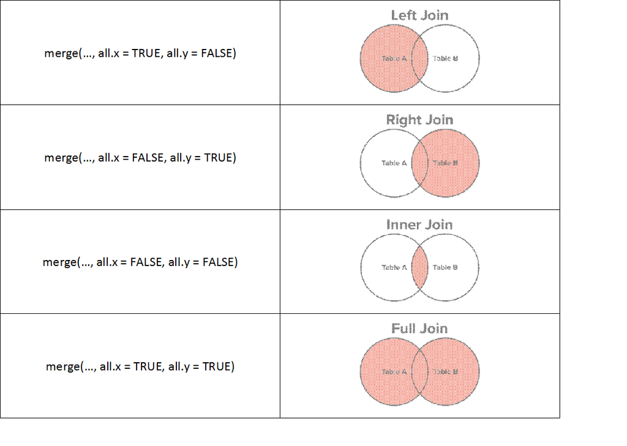

בשביל להדגים, קודם:

- ניצור טבלה המחשבת את הממוצע של `Sepal.Length` לפי העמודה `Species`
- ונשנה את שם העמודה המחושבת ל `MeanLength`
- ונחליף את הערך `setosa` בעמודת המפתח `Species` בערך NA

```r
# Calculate aggregated table
irisMean <- aggregate(Sepal.Length ~ Species, data = irisdata, mean)

# Rename the Calculated Coloumn
names(irisMean)[2] <- "MeanLength"

# Replace setosa with NA
irisMean$Species[irisMean$Species=="setosa"] <- NA
```

- עכשיו נדגים חיבור לערכי הבטלה הראשונה (left join) בין 2 הטבלאות לפי המפתח `Species`

```r
# Do a left join
irisdata <- merge(irisdata, irisMean,
                   by.x = "Species", by.y = "Species",
                   all.x = TRUE,
                   all.y = FALSE)

irisdata[48:53,]
```

|  | Species | Sepal.Length | Sepal.Width | Petal.Length | Petal.Width | NewCol2 | MeanLength |
| --- | --- | --- | --- | --- | --- | --- | --- |
| 48 | setosa | 5.4 | 3.4 | 1.7 | 0.2 | 21 | NA |
| 49 | setosa | 5.7 | 3.8 | 1.7 | 0.3 | 19 | NA |
| 50 | setosa | 5.7 | 4.4 | 1.5 | 0.4 | 16 | NA |
| 51 | versicolor | 5.9 | 3.0 | 4.2 | 1.5 | 62 | 5.936 |
| 52 | versicolor | 5.2 | 2.7 | 3.9 | 1.4 | 60 | 5.936 |
| 53 | versicolor | 6.0 | 2.9 | 4.5 | 1.5 | 79 | 5.936 |

# תרגיל

בתרגיל הבא תעשו שימוש במה שלמדתם ותעזרו בפקודות הבאות על מנת לענות על השאלות:

- `summary` : פקודה המחזירה סטטיסטיקה בסיסית על טבלה או וקטור
- `table` : פקודה גנרית המחזירה טבלת התפלגות של וקטור על וקטור (ספירה של עמודה אחת מול השניה)
- `prop.table` : מקבל אובייקט שנוצר מפקודת `table`. ומקבל עוד פרמטר מספר 1 עד 3 לפיו מחזיר את שיעור הערכים לפי שורה (1) , עמודה (2), או סך הכל
- `levels` : מחזיר את הקטגוריות היחודיות עבור משתנה מסוג `factor`
- `mean` : חישוב ממוצע של וקטור / עמודה
- `plot` : פקודה גנרית המייצרת גרף בהתאם לאובייקטים המעוברים עליה
- `ls` : מחזיר רשימה של שמות האובייקטים הקיימים בסביבה מסוימת
- `rm` : מחיקת משתנה

וכל פקודה אחרת שתשיג את המטרה…

העזרו ב `help` אם אתם לא יודעים איך להשתמש בפקודה מסוימת

## Answers

```r
iris_data <- iris

str(iris_data)
```

```
## 'data.frame':    150 obs. of  5 variables:
##  $ Sepal.Length: num  5.1 4.9 4.7 4.6 5 5.4 4.6 5 4.4 4.9 ...
##  $ Sepal.Width : num  3.5 3 3.2 3.1 3.6 3.9 3.4 3.4 2.9 3.1 ...
##  $ Petal.Length: num  1.4 1.4 1.3 1.5 1.4 1.7 1.4 1.5 1.4 1.5 ...
##  $ Petal.Width : num  0.2 0.2 0.2 0.2 0.2 0.4 0.3 0.2 0.2 0.1 ...
##  $ Species     : Factor w/ 3 levels "setosa","versicolor",..: 1 1 1 1 1 1 1 1 1 1 ...
```

```r
levels(iris_data$Species)
```

```
## [1] "setosa"     "versicolor" "virginica"
```

```r
summary(iris_data)
```

|  | Sepal.Length | Sepal.Width | Petal.Length | Petal.Width | Species |
| --- | --- | --- | --- | --- | --- |
|  | Min. :4.300 | Min. :2.000 | Min. :1.000 | Min. :0.100 | setosa :50 |
|  | 1st Qu.:5.100 | 1st Qu.:2.800 | 1st Qu.:1.600 | 1st Qu.:0.300 | versicolor:50 |
|  | Median :5.800 | Median :3.000 | Median :4.350 | Median :1.300 | virginica :50 |
|  | Mean :5.843 | Mean :3.057 | Mean :3.758 | Mean :1.199 | NA |
|  | 3rd Qu.:6.400 | 3rd Qu.:3.300 | 3rd Qu.:5.100 | 3rd Qu.:1.800 | NA |
|  | Max. :7.900 | Max. :4.400 | Max. :6.900 | Max. :2.500 | NA |

```r
# This does not give the expected result!!
# And worse - Doesnt throw an Error!!
table(iris_data["Sepal.Length">5,"Species"])
```

| setosa | versicolor | virginica |
| --- | --- | --- |
| 50 | 50 | 50 |

```r
# Option 1
table(iris_data[iris_data$Sepal.Length>5,"Species"])
```

| setosa | versicolor | virginica |
| --- | --- | --- |
| 22 | 47 | 49 |

```r
# Option 2
table(subset(iris_data, Sepal.Length>5, c("Species")))
```

| setosa | versicolor | virginica |
| --- | --- | --- |
| 22 | 47 | 49 |

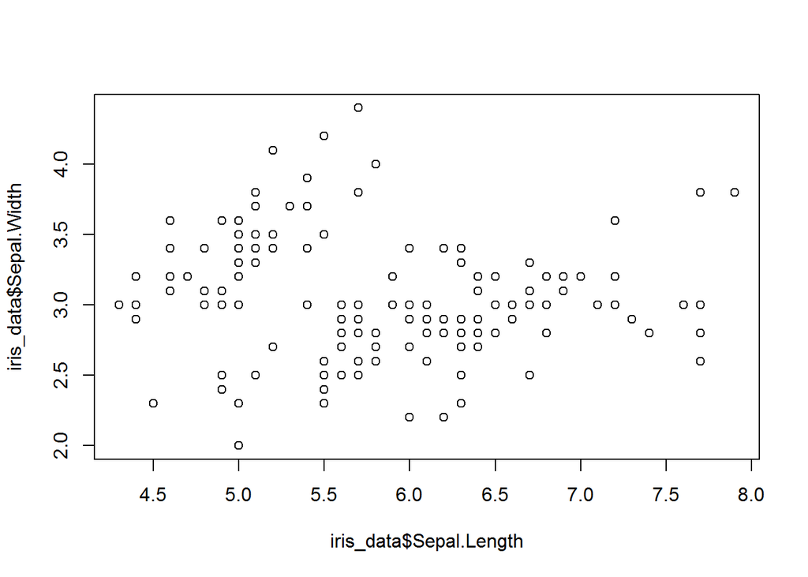

```r
plot(iris_data$Sepal.Length, iris_data$Sepal.Width)
```

```r
iris_data$Grp_Length <- 0
iris_data$Grp_Length[iris_data$Sepal.Length>=5] <- 1

# Lets look at a summary to make sure we are right

aggregate(Sepal.Length ~ Grp_Length, data =iris_data, max)
```

| Grp_Length | Sepal.Length |
| --- | --- |
| 0 | 4.9 |
| 1 | 7.9 |

```r
sumTable <- table(iris_data$Species, iris_data$Grp_Length)
```

```r
prop.table(sumTable,1)
```

| / | 0 | 1 |
| --- | --- | --- |
| setosa | 0.40 | 0.60 |
| versicolor | 0.02 | 0.98 |
| virginica | 0.02 | 0.98 |

```r
prop.table(sumTable,2)
```

| / | 0 | 1 |
| --- | --- | --- |
| setosa | 0.9090909 | 0.2343750 |
| versicolor | 0.0454545 | 0.3828125 |
| virginica | 0.0454545 | 0.3828125 |

```r
prop.table(sumTable)
```

| / | 0 | 1 |
| --- | --- | --- |
| setosa | 0.1333333 | 0.2000000 |
| versicolor | 0.0066667 | 0.3266667 |
| virginica | 0.0066667 | 0.3266667 |

```r
iris_data$Sepal.Length[iris_data$Grp_Length == 0] <- NA

# Unpredictable NA actions

# This returns the expected answer
summary(iris_data$Sepal.Length)
```

| Min. | 1st Qu. | Median | Mean | 3rd Qu. | Max. | NA’s |
| --- | --- | --- | --- | --- | --- | --- |
| 5 | 5.5 | 6 | 6.041 | 6.5 | 7.9 | 22 |

```r
# This doesnt return the expected answer
mean(iris_data$Sepal.Length)
```

```
## [1] NA
```

```r
# This does
mean(iris_data$Sepal.Length, na.rm = TRUE)
```

```
## [1] 6.041406
```

```r
# Option 1
iris_data$Grp_Length <- NULL

# Option 2
iris_data <- iris_data[,-6]
```

```r
1:5
```

```
## [1] 1 2 3 4 5
```

```r
1:2
```

```
## [1] 1 2
```

```r
1:5 + 1:2
```

```
## [1] 2 4 4 6 6
```

```r
# See whats going on - recycling...
```

```r
# get a list of whats in the current environment

ls()
```

```
## [1] "iris_data"     "irisdata"      "irisdata2"     "irisMean"
## [5] "NewCol2"       "originalNames" "sumTable"
```

```r
# this erases everything in our environment

rm(list = ls(.GlobalEnv))
```

# חומר קריאה לעומק

“Advanced R, Hadley Wickham, Chapters 1-4” at http://adv-r.had.co.nz/

“The R Inferno, Patrick Burns, Chapter 8” at http://www.burns-stat.com/documents/books/the-r-inferno/